# Finalish cameras

I think I have all the data I need to run the productivity ~ diet models. So here goes…

```r
# Import conflict settings.
source('../src/conflicted.R')

# Load some libraries.
library(tidyverse)
library(lubridate)
library(ggplot2)
library(vegan)
library(broom.mixed)
library(lme4)
library(purrr)
library(modelr)

# Bring in camera data.
camera.data <- read_csv('../data/interim/cameras_20210315.csv', guess_max=7000) %>%
  ## filter only records with at least size assigned...
  filter(size != 'U')

# To make sure the average sizes work, I also need to bring in the physical remains.
remains.data <- read_csv('../data/raw/20210118_specimens.csv', guess_max=7000) %>%
  ## filter only records with at least size assigned...
  filter(size != 'U') %>%
  ## and rename a confusing column.
  rename(name=site) %>%
  ## and fix a typo
  mutate(genus=case_when(
    genus == 'Picoides' ~ 'Dryobates',
    TRUE ~ genus
  ))

# Bring in a list of site abbreviations and site names.
nest.list <- read_csv('../data/processed/site_abbreviations.csv')

# Standardize the specimen data.
remains.data <- left_join(remains.data, nest.list, by='name') %>%
  filter(id != 1120) %>%
  filter(id != 1171) %>%
  filter(site != 'COM') %>%
  select(site, date, class, order, family, genus, species, common, size, age, source)

# Standardize the camera data.
camera.data <- camera.data %>%
  mutate(date=date(datetime), source='C') %>%
  select(site, date, class, order, family, genus, species, common, size, age, source)

# Join them together.
diet.data <- bind_rows(remains.data, camera.data)

# Add a unique site/year identifier.
diet.data <- diet.data %>%
  mutate(year=year(date), nest=paste(site, year, sep=''))

# Do some cleanup.
diet.data <- diet.data %>%
  mutate(size=case_when(
    size %in% c('S', 'Small') ~ 'small',
    size %in% c('M', 'Medium') ~ 'medium',
    size %in% c('L', 'Large') ~ 'large'
  )) %>%
  ## and replace all the "U"s with "Unknown"...
  mutate_at(c('class', 'order', 'family', 'genus'), funs(case_when(
    . == 'U' ~ 'Unknown',
    TRUE ~ .
  ))) %>%
  ## in species as well...
  mutate(species=case_when(
    species == 'U' ~ 'unknown',
    TRUE ~ species
  ))
```

That’s the diet data from cameras brought in. Time to add the mass data.

```r
# Bring in a list of all known prey.
prey.list <- read_csv('../data/interim/prey_attributes.csv')

# Join the biomass data to the list of diet items.
diet.items <- prey.list %>% select(genus, species, binomial, common, category, mass) %>%
  right_join(diet.data, by=c('genus', 'species', 'common'))

# For unidentified items, classify them by size and class.
diet.items <- diet.items %>% mutate(category=case_when(
  is.na(category) & class == 'Mammalia' & size == 'small' ~ 'small mammal',
  is.na(category) & class == 'Mammalia' & size == 'medium' ~ 'medium mammal',
  is.na(category) & class == 'Mammalia' & size == 'large' ~ 'large mammal',
  is.na(category) & class == 'Aves' & size == 'small' ~ 'small bird',
  is.na(category) & class == 'Aves' & size == 'medium' ~ 'medium bird',
  is.na(category) & class == 'Aves' & size == 'large' ~ 'large bird',
  is.na(category) & class == 'Unknown' ~ paste(size, 'item'),
  TRUE ~ category))

# For unidentified items, fill in the binomial column.
diet.items <- diet.items %>% replace_na(list(binomial = 'Unidentified item'))

# Calculate average masses for unidentified items, based of known species.
mean.mass <- diet.items %>% drop_na(mass) %>%
  distinct(binomial, mass, category) %>%
  group_by(category) %>%
  ## averaging the mass for each size & class category...
  summarize(average=mean(mass)) %>%
  pivot_wider(names_from=category, values_from=average) %>%
  ## calculating the average mass for complete unknowns...
  mutate(`large item` = mean(`large bird`, `large mammal`),
         `medium item` = mean(`medium bird`, `medium mammal`),
         `small item` = mean(`small bird`, `small mammal`)) %>%
  ## and reassembling it in a tidy format.
  pivot_longer(everything(), names_to='category', values_to='average')

# Join average mass to diet items...
diet.items <- left_join(diet.items, mean.mass, by='category') %>%
  ## and fill in missing mass with average values
  mutate(mass=coalesce(mass, average)) %>%
  ## then drop no longer needed average column and rearrange.
  select(site, year, nest, class, order, family, genus, species, binomial, common,
         category, size, age, mass, source)
```

Looks good. One last thing to change is that juveniles need to have smaller mass than adults. This is a completely arbitrary choice. I don’t think I have any small species juveniles, only large and mediums. Miller uses 65-95% of adults mass for medium birds and 55-95% for large birds, and 50% for mammals. That seems incredibly fine considering the coarseness of my data, so maybe I’ll just go with a flat 50%?

```r
# Change mass for juvenile items.
diet.items <- diet.items %>% mutate(mass=case_when(
  age == 'J' ~ 0.5*mass,
  TRUE ~ mass
))
```

Ok, now on to doing all the calculations needed to get things ready for the models.

```r
# Make a function to calculate class mass.
class.mass <- function(data) {
    data %>% mutate(total.mass=sum(.data$mass)) %>%
    filter(class %in% c('Mammalia', 'Aves')) %>%
    group_by(class) %>%
    mutate(class.mass=sum(.data$mass), per.class=class.mass/total.mass*100) %>%
    distinct(class, per.class) %>%
    rename(variable=class, percent=per.class)
}

# And a function to calculate squirrel mass.
squirrel.mass <- function(data) {
    data %>% mutate(total.mass=sum(.data$mass)) %>%
    filter(genus == 'Tamiasciurus') %>%
    mutate(genus.mass=sum(.data$mass), per.genus=genus.mass/total.mass*100) %>%
    distinct(genus, per.genus) %>%
    rename(variable=genus, percent=per.genus)
}

# Calculate percent mass for each nest.
nest.mass <- diet.items %>% filter(source == 'C') %>%
  group_by(nest) %>% nest() %>%
  mutate(class=map(data, class.mass),
         genus=map(data, squirrel.mass)) %>%
  pivot_longer(-c(nest, data), names_to='var', values_to='per') %>%
  unnest(per) %>%
  select(nest, variable, percent) %>%
  pivot_wider(id_cols=c(nest), names_from=variable, values_from=percent, values_fill=0)

# Calculate counts of items identified to genus for each nest.
nest.count <- diet.items %>% filter(source == 'C' & binomial != 'Unidentified item') %>%
  group_by(nest, binomial) %>%
  mutate(count=n()) %>%
  select(nest, binomial, count) %>%
  distinct() %>%
  pivot_wider(names_from=binomial, values_from=count, values_fill=list(count = 0))

# Diversity per nest.
nest.diversity <- plyr::ddply(nest.count, ~nest, function(x) {
  data.frame(diet.diversity=diversity(x[-1], index='simpson'))
})
```

Calculations done, wrangle it all into a tidy data set.

```r
# Bring in productivity data.
productivity <- read_csv('../data/raw/productivity.csv')

# Make a happy data set for the models to use.
model.data <- productivity %>% mutate(nest=paste(site, year, sep='')) %>%
  left_join(nest.diversity, by=c('nest')) %>%
  left_join(nest.mass, by=c('nest')) %>%
  select(site, year, nest, n.fledge, diet.diversity, Tamiasciurus) %>%
  filter_all(all_vars(!is.na(.)))

model.data
```

| site | year | nest | n.fledge | diet.diversity | Tamiasciurus |
| --- | --- | --- | --- | --- | --- |
| TCR | 2019 | TCR2019 | 2 | 0.6080000 | 50.13705 |
| MTC | 2019 | MTC2019 | 1 | 0.5798611 | 54.57177 |
| UTZ | 2019 | UTZ2019 | 2 | 0.7159763 | 48.74535 |
| TMC | 2019 | TMC2019 | 0 | 0.6505190 | 26.89225 |
| MTF | 2019 | MTF2019 | 2 | 0.5432526 | 53.10623 |
| RLK | 2019 | RLK2019 | 3 | 0.2448980 | 51.56479 |
| MTF | 2020 | MTF2020 | 1 | 0.4099723 | 49.62552 |
| PCR | 2020 | PCR2020 | 1 | 0.4201389 | 65.67922 |
| PNC | 2020 | PNC2020 | 2 | 0.0000000 | 56.14858 |
| GOW | 2020 | GOW2020 | 1 | 0.3112500 | 50.76571 |

[output cut: 1 more lines]

PNC looks wrong because the diversity is 0, but that is technically correct: the only things identified with any level of precision were squirrels.

Before we make the models, let’s look at some graphs.

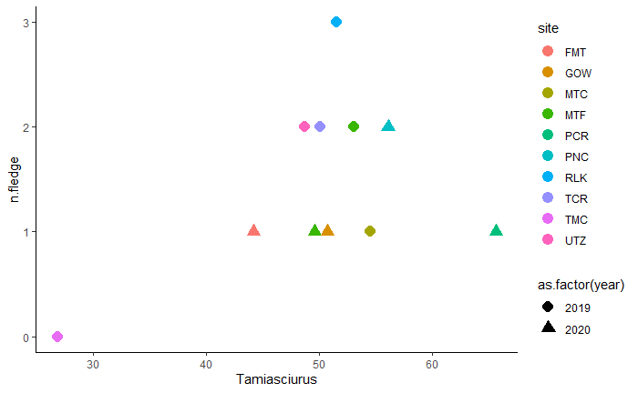

```r
# All the data together.
ggplot(model.data, aes(x=Tamiasciurus, y=n.fledge, color=site, shape=as.factor(year))) +
  geom_point(size=4) +
  theme_classic()
```

And break it apart to make it a little easier to see.

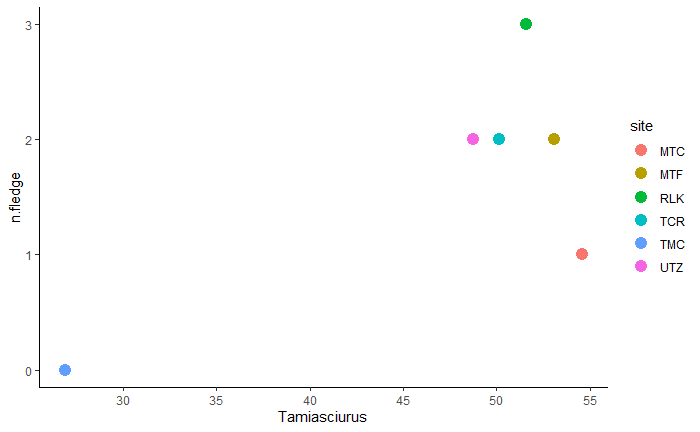

```r
# 2019.
model.data %>% filter(year == 2019) %>%
  ggplot(aes(x=Tamiasciurus, y=n.fledge, color=site)) +
  geom_point(size=4) +
  ylim(0, 3) +
  theme_classic()
```

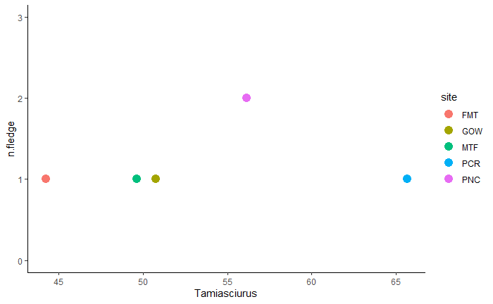

```r
# 2020.
model.data %>% filter(year == 2020) %>%
  ggplot(aes(x=Tamiasciurus, y=n.fledge, color=site)) +
  geom_point(size=4) +
  ylim(0, 3) +
  theme_classic()
```

Let’s try making some models.

```r
# Start with just squirrels.
squirrel.model <- lmer(n.fledge ~ Tamiasciurus + (1|year), data=model.data)

# Look at it.
summary(squirrel.model)
```

```
Linear mixed model fit by REML ['lmerMod']
Formula: n.fledge ~ Tamiasciurus + (1 | year)
   Data: model.data

REML criterion at convergence: 29.6

Scaled residuals:
    Min      1Q  Median      3Q     Max
-1.2884 -0.5673  0.1333  0.4965  1.7681

Random effects:
 Groups   Name        Variance Std.Dev.
 year     (Intercept) 0.1906   0.4366
 Residual             0.5013   0.7081
Number of obs: 11, groups:  year, 2

Fixed effects:
             Estimate Std. Error t value
(Intercept)  -0.91977    1.29618  -0.710
Tamiasciurus  0.04691    0.02466   1.902

Correlation of Fixed Effects:
            (Intr)
Tamiasciurs -0.957
```

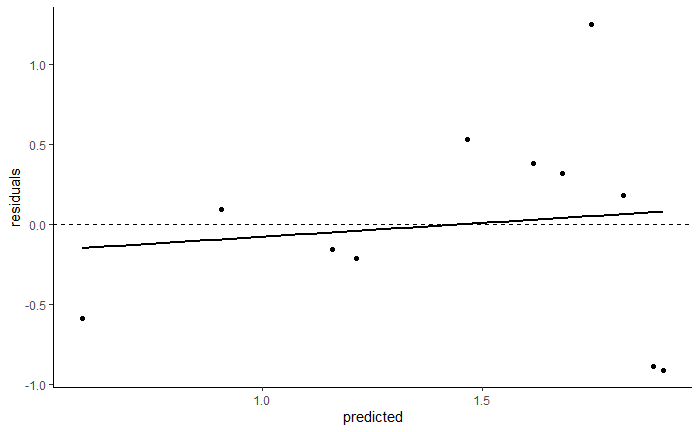

```r
# Look at some diagnostics.
data.frame(predicted=predict(squirrel.model, type='response'),
           residuals=residuals(squirrel.model, type='response')) %>%
  ggplot(aes(x=predicted, y=residuals)) +
  geom_point() +
  geom_hline(yintercept=0, linetype='dashed') +
  geom_smooth(method='lm', formula='y~x', se=FALSE, color='black') +
  theme_classic()
```

Because there is only one site repeated between years, it’s probably not crazy to run this as a simple linear model.

```r
# Try it without MTF in 2019.
mod1 <- model.data %>% filter(nest != 'MTF2019') %>% lm(n.fledge ~ Tamiasciurus, data=.)

# Try it without MTF in 2020.
mod2 <- model.data %>% filter(nest != 'MTF2020') %>% lm(n.fledge ~ Tamiasciurus, data=.)

# Try it with both.
mod3 <- model.data %>% lm(n.fledge ~ Tamiasciurus, data=.)

# Put them all in a data frame.
mods <- tribble(~name, ~model, ~data,
        'mod1', mod1, model.data,
        'mod2', mod2, model.data,
        'mod3', mod3, model.data)

# Calculate some stuff.
mods <- mods %>% mutate(gl=map(model, glance), td=map(model, tidy))

# Look at them.
mods %>% unnest(gl)
```

| name | model | data | r.squared | adj.r.squared | sigma | statistic | p.value | df | logLik | AIC | BIC | deviance | df.residual | td |
| --- | --- | --- | --- | --- | --- | --- | --- | --- | --- | --- | --- | --- | --- | --- |
| mod1 |  |  | 0.1817423 | 0.07946010 | 0.8090773 | 1.776871 | 0.2192450 | 2 | -10.95506 | 27.91012 | 28.81788 | 5.236849 | 8 |  |
| mod2 |  |  | 0.1944217 | 0.09372443 | 0.8090317 | 1.930754 | 0.2021241 | 2 | -10.95450 | 27.90899 | 28.81675 | 5.236259 | 8 |  |
| mod3 |  |  | 0.1906495 | 0.10072164 | 0.7777976 | 2.120027 | 0.1793642 | 2 | -11.74046 | 29.48091 | 30.67460 | 5.444722 | 9 |  |

```r
mods %>% unnest(td) %>% arrange(term, name)
```

| name | model | data | gl | term | estimate | std.error | statistic | p.value |
| --- | --- | --- | --- | --- | --- | --- | --- | --- |
| mod1 |  |  |  | (Intercept) | -0.41551186 | 1.38580428 | -0.2998344 | 0.7719462 |
| mod2 |  |  |  | (Intercept) | -0.39541908 | 1.38787023 | -0.2849107 | 0.7829491 |
| mod3 |  |  |  | (Intercept) | -0.45269436 | 1.33071671 | -0.3401884 | 0.7415199 |
| mod1 |  |  |  | Tamiasciurus | 0.03643041 | 0.02732977 | 1.3329933 | 0.2192450 |
| mod2 |  |  |  | Tamiasciurus | 0.03777004 | 0.02718216 | 1.3895158 | 0.2021241 |
| mod3 |  |  |  | Tamiasciurus | 0.03804402 | 0.02612857 | 1.4560314 | 0.1793642 |

None of them are anything like significant. This is a problem because even when you pull out just the 2019 data it stays insignificant.

```r
# Run with just 2019 data.
model.data %>% filter(year == 2019) %>% lm(n.fledge ~ Tamiasciurus, data=.) %>% summary()
```

```
Call:
lm(formula = n.fledge ~ Tamiasciurus, data = .)

Residuals:
       1        2        3        4        5        6
 0.14382 -1.17525  0.24394 -0.18379 -0.06981  1.04109

Coefficients:
             Estimate Std. Error t value Pr(>|t|)
(Intercept)  -1.75102    1.68881  -1.037    0.358
Tamiasciurus  0.07195    0.03487   2.063    0.108

Residual standard error: 0.8037 on 4 degrees of freedom
Multiple R-squared:  0.5155,    Adjusted R-squared:  0.3944
F-statistic: 4.256 on 1 and 4 DF,  p-value: 0.1081
```

This is an even bigger problem because when I try to re-run my “storytime” code, which originally produced such a nice p-value, I cannot reproduce those results: the p-value is still non-significant.

So in summary

- running with two years of data produces no significant results
- running with one year of data produces no significant results, even though it did previously
- running with original code produces no significant results, even though it did previously
- I am unable to reproduce previous results, I have no explanation for why, and I therefore have no evidence previous significant results were every actually real

I can go over my data very carefully to see if I’ve made a huge mistake in this most recent iteration of the data set but it seems unlikely.

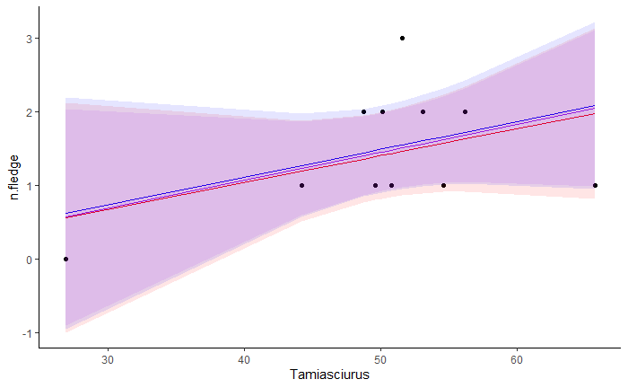

```r
# Make some confidence intervals, etc.
pred1 <- predict(mod1, interval='confidence')
pred1 <- model.data %>% filter(nest != 'MTF2019') %>% cbind(pred1)

pred2 <- predict(mod2, interval='confidence')
pred2 <- model.data %>% filter(nest != 'MTF2020') %>% cbind(pred2)

pred3 <- predict(mod3, interval='confidence')
pred3 <- model.data %>% cbind(pred3)

# Plot them.
ggplot() +
  geom_point(data=model.data, aes(x=Tamiasciurus, y=n.fledge)) +
  geom_line(data=pred1, aes(x=Tamiasciurus, y=fit), color='red') +
  geom_line(data=pred2, aes(x=Tamiasciurus, y=fit), color='blue') +
  geom_line(data=pred3, aes(x=Tamiasciurus, y=fit), color='purple') +
  geom_ribbon(data=pred1, aes(x=Tamiasciurus, y=fit, ymin=lwr, ymax=upr), fill='red', alpha=0.1) +
  geom_ribbon(data=pred2, aes(x=Tamiasciurus, y=fit, ymin=lwr, ymax=upr), fill='blue', alpha=0.1) +
  geom_ribbon(data=pred3, aes(x=Tamiasciurus, y=fit, ymin=lwr, ymax=upr), fill='purple', alpha=0.1) +
  theme_classic()
```

So no real difference whether one or the other is included, or both.

One last item for David:

```r
glm(n.fledge ~ Tamiasciurus, family=poisson, data=model.data) %>% summary()
```

```
Call:
glm(formula = n.fledge ~ Tamiasciurus, family = poisson, data = model.data)

Deviance Residuals:
    Min       1Q   Median       3Q      Max
-1.1869  -0.4494  -0.1706   0.4124   1.1054

Coefficients:
             Estimate Std. Error z value Pr(>|z|)
(Intercept)  -1.15161    1.66738  -0.691    0.490
Tamiasciurus  0.02979    0.03156   0.944    0.345

(Dispersion parameter for poisson family taken to be 1)

    Null deviance: 5.6918  on 10  degrees of freedom
Residual deviance: 4.7295  on  9  degrees of freedom
AIC: 32.176

Number of Fisher Scoring iterations: 5
```

```r
glm(n.fledge ~ diet.diversity, family=poisson, data=model.data) %>% summary()
```

```
Call:
glm(formula = n.fledge ~ diet.diversity, family = poisson, data = model.data)

Deviance Residuals:
    Min       1Q   Median       3Q      Max
-1.5637  -0.4328  -0.1943   0.5645   0.8704

Coefficients:
               Estimate Std. Error z value Pr(>|z|)
(Intercept)      0.7612     0.5440   1.399    0.162
diet.diversity  -0.8612     1.1277  -0.764    0.445

(Dispersion parameter for poisson family taken to be 1)

    Null deviance: 5.6918  on 10  degrees of freedom
Residual deviance: 5.1332  on  9  degrees of freedom
AIC: 32.58

Number of Fisher Scoring iterations: 5
```

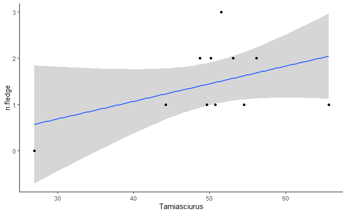

```r
ggplot(model.data, aes(x=Tamiasciurus, y=n.fledge)) +
  geom_smooth(method='glm', formula='y ~ x') +
  geom_point() +
  theme_classic()
```